# Geostatistics

5 november, 2021

This is the first assignment in Spatial Epidemiology at UPC, fall 2021. It is in the topic of Geostatistics. Don’t know if we should write anything else in this “intro”.

## Load libraries and data

```r
# The libraries we used.
library(geoR)
library(sm)
library(gstat)

coordinates <- read.table("poly84.txt", head = TRUE, sep = "\t", dec = ".")
elevs <- read.table("elevationsIslet.txt", head = TRUE, sep = "\t", dec = ".")
head(elevs)
```

```
#>           x          y data
#> 1  98.57754  0.8906123 17.6
#> 2 113.59737 19.5085930 27.1
#> 3 110.53511 39.6851815 16.4
#> 4 105.27965 28.3568305 -9.5
#> 5  95.20204  8.4319902  6.1
#> 6 102.96788 53.0629008 -0.5
```

## 1. Exploration of the large scale variability of the elevation

In this problem we will explore the large scale variability of the elevation data.

```r
geoelevs <- as.geodata(elevs)
summary(geoelevs)
```

```
#> Number of data points: 148
#>
#> Coordinates summary
#>            x         y
#> min   0.0000 -70.00000
#> max 116.5471  81.88936
#>
#> Distance summary
#>         min         max
#>   0.2104305 152.5866269
#>
#> Data summary
#>     Min.  1st Qu.   Median     Mean  3rd Qu.     Max.
#> -9.50000  7.67500 16.35000 15.97095 24.17500 39.60000
```

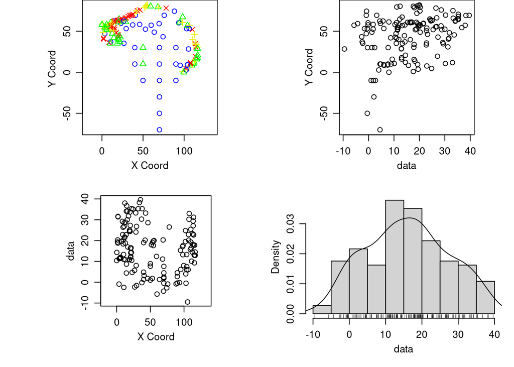

```r
plot(geoelevs)
```

```r
# Remember that:
###   (circles) : 1st quartile
###   (triangles) : 2nd quartile
###   (plus)  : 3rd quartile
###   (crosses)  : 4th quartile
```

The following plots further ground the initial theories about the trends in the latitude and longitude.

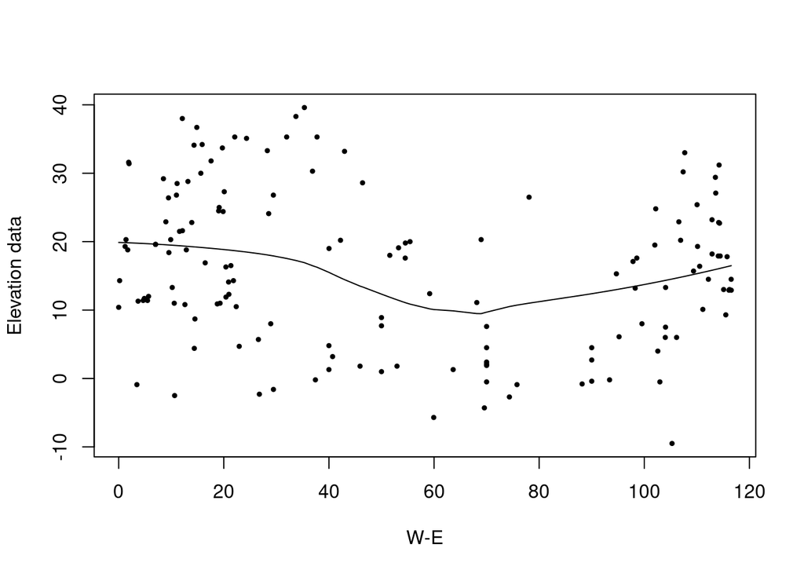

```r
with(geoelevs, plot(coords[, 1], data, xlab = "W-E",
              ylab = "Elevation data", pch = 20, cex = 0.7))
lines(with(geoelevs, lowess(data ~ coords[, 1])))
```

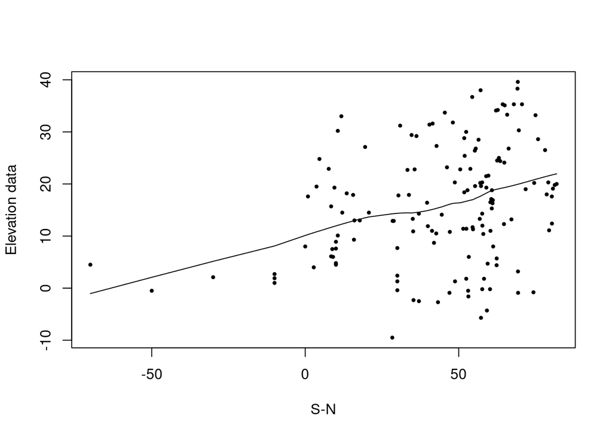

```r
with(geoelevs, plot(coords[, 2], data, xlab = "S-N",
              ylab = "Elevation data", pch = 20, cex = 0.7))
lines(with(geoelevs, lowess(data ~ coords[, 2])))
```

Attempting to remove the trends with a linear model. The residuals of the linear regression are added to a new dataframe, with the original data.

```r
lm.fit <- lm(data ~ y + poly(x,2), data = elevs)
summary(lm.fit)
```

```
#>
#> Call:
#> lm(formula = data ~ y + poly(x, 2), data = elevs)
#>
#> Residuals:
#>     Min      1Q  Median      3Q     Max
#> -23.845  -6.301  -1.079   6.571  23.226
#>
#> Coefficients:
#>             Estimate Std. Error t value Pr(>|t|)
#> (Intercept) 10.18780    1.81117   5.625 9.35e-08 ***
#> y            0.13223    0.03658   3.615 0.000415 ***
#> poly(x, 2)1 -7.12030   11.65722  -0.611 0.542291
#> poly(x, 2)2 39.06998   10.41746   3.750 0.000255 ***
#> ---
#> Signif. codes:  0 '***' 0.001 '**' 0.01 '*' 0.05 '.' 0.1 ' ' 1
#>
#> Residual standard error: 10.33 on 144 degrees of freedom
#> Multiple R-squared:  0.1754, Adjusted R-squared:  0.1583
#> F-statistic: 10.21 on 3 and 144 DF,  p-value: 3.862e-06
```

```r
# Add residuals to a new data frame.
elevs2 <- data.frame(elevs, residuals = lm.fit$residuals)
geoelevs2 <- as.geodata(elevs2, data.col = 4)
```

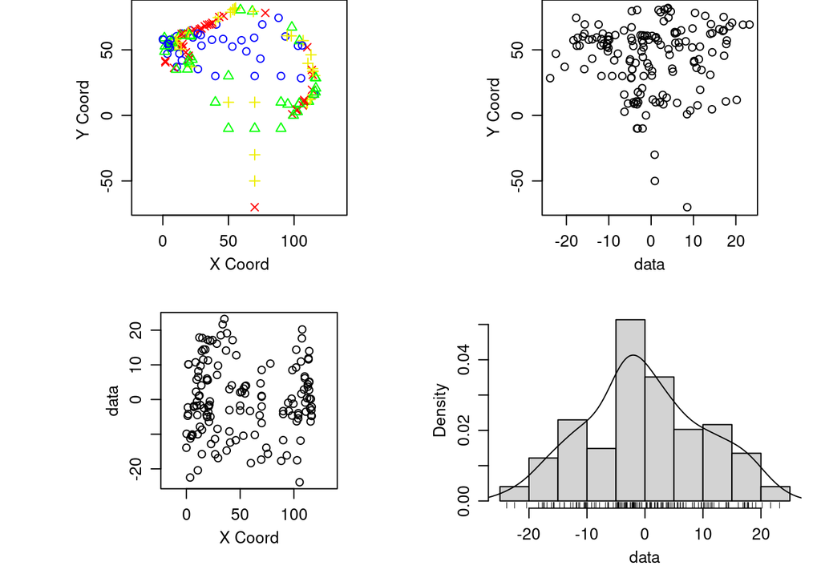

```r
plot(geoelevs2)
```

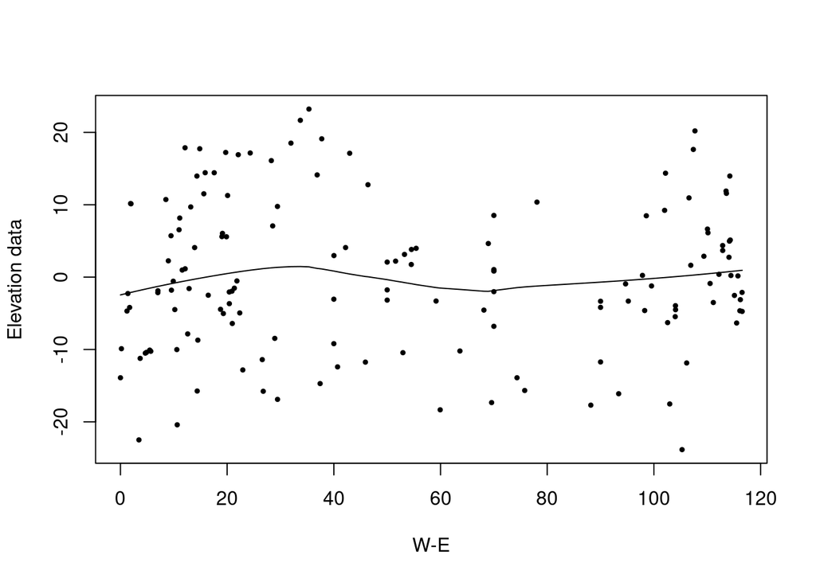

```r
with(geoelevs2, plot(coords[, 1], data, xlab = "W-E",
                  ylab = "Elevation data", pch = 20, cex = 0.7))
lines(with(geoelevs2, lowess(data ~ coords[, 1])))
```

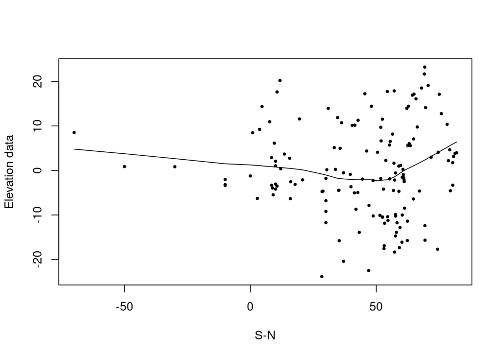

```r
with(geoelevs2, plot(coords[, 2], data, xlab = "S-N",
                  ylab = "Elevation data", pch = 20, cex = 0.7))
lines(with(geoelevs2, lowess(data ~ coords[, 2])))
```

It looks like some of the trend has been removed, i.e. the linear model has explained some of the variations in the data. Note that we also attempted different combinations of dropping the second order term in longitude and adding a second order term in latitude, but chose the above model for its simplicity and reasonably good performance. It is the simplest model among those we tried, where all the models had very similar residuals. Note that this is by no means a rigorous analysis when applying the linear model, but we have chosen the simplest model that seems to remove some of the trend in the data. Therefore, we will use the residuals from the linear regression in the rest of the analysis.

## 2. Exploration of the small scale variability of the elevation

In this problem we will explore the small scale variability of the elevation data.

First we calculate and plot the variogram cloud together with the empirical variogram. Remember that we now are analyzing the residuals from the linear regression presented earlier. Note that the robust estimator (`modulus`, Hawkins and Cressie 1993) is used when estimating the empirical variogram.

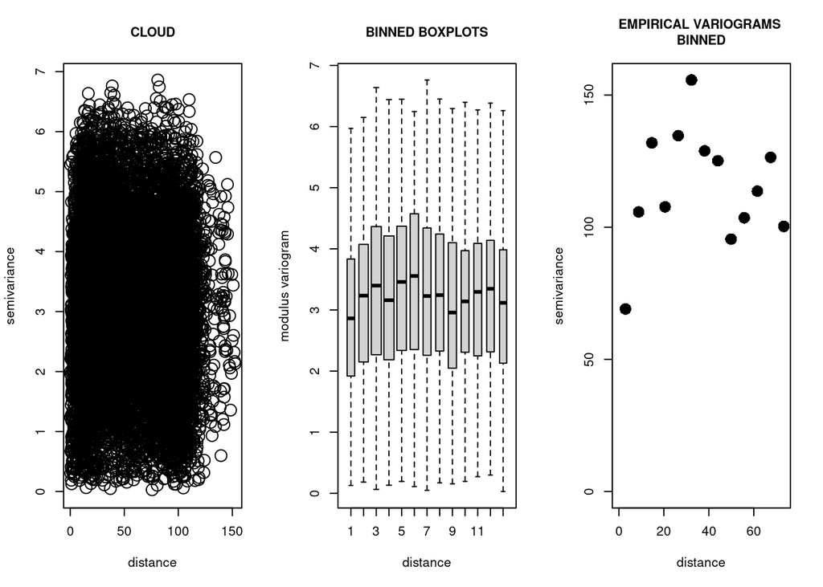

```r
# Practical rules: lags only up to half of maxdist. That is why maxdist is saved here.
maxdist <- max(dist(cbind(elevs$x,elevs$y)))
cloud <- variog(geoelevs2, option = "cloud", estimator.type = "modulus")
bp <- variog(geoelevs2, option = "bin", bin.cloud = T,
               pairs.min=30, max.dist=maxdist/2,
               estimator.type = "modulus")
bin <- variog(geoelevs2, option = "bin", pairs.min=30, max.dist=maxdist/2,
                estimator.type = "modulus")
# Also: pairs,min = 30 since the sample variogram should only be considered for lags
# that have more than 30 pairs.

par(mfrow=c(1,3))
plot(cloud,main="CLOUD", cex.main=1, cex.lab=1, cex=2)
plot(bp, bin.cloud=T, cex.lab=1)
title(main = "BINNED BOXPLOTS", cex.main=1)
plot(bin, main="EMPIRICAL VARIOGRAMS \nBINNED",cex.main=1, cex.lab=1, cex=2, pch=16)
```

From these variogram plots it looks like the range of a variogram is approx. 30 (distance), the sill around 150 (semivariance) and the nugget might be around 30. Thus, one might say that there is spatial correlation, at least in a range of 30.

Will calculate directional variograms to study isotropic/anistropic properties also.

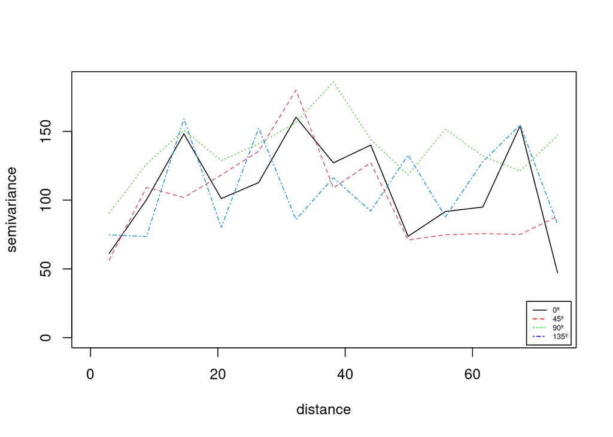

```r
par(mfrow=c(1, 1))
variod <- variog4(geoelevs2,max.dist=maxdist/2, pairs.min=30,estimator.type = "modulus")
plot(variod,lyt=2,legend=FALSE)
legend(x="bottomright", inset=0.01, lty=c(1,2,3,4), col=c("black", "red", "green","blue"),
       legend=c("0º", "45º", "90º","135º"), cex=0.5)
```

We think the data looks relatively isotropic, at least based on the 4 directions plotted above, which look relatively similar to each other.

## 3. Exploration of the spatial independence

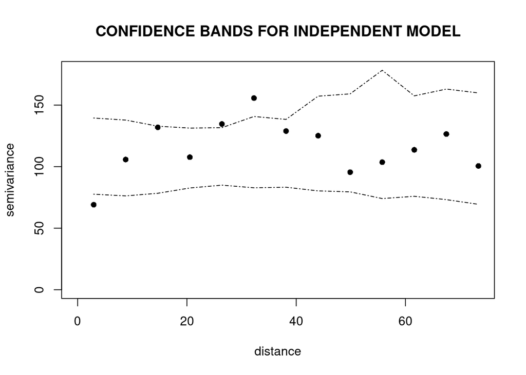

```r
set.seed(10000)
par(mfrow=c(1,1))
indep.env <- variog.mc.env(geoelevs2, coords=geoelevs2$coords,
                        data=geoelevs2$data, obj.variog=bp, nsim=200)
plot(bp, envelope = indep.env, main="CONFIDENCE BANDS FOR INDEPENDENT MODEL",
                        lwd=2, pch=16)
```

The confidence bands show a range of estimated variograms when the measurements are randomly allocated to the spatial points. The lower confidence band is the minimum value of the variogram for the simulated data in each lag and, similarly, the upper confidence band is the maximum value. The hypothesis that the process is independent may be rejected if the empirical variaogram falls outside these confidence bands, since this would indicate that it is unplausible that the variaogram has those values by chance. The plot shows that three of the points are outside the confidence bands, which indicates that complete spatial randomness in the underlying process may be unplausible. This depends on the seed used to generate pseudorandom numbers, but it seems like the conclusion holds with other seeds also.

We will also add a Rose diagram, to study the anisotropy further. The Rose diagram will be plotted used the code supplied in the lectures (`RoseDiagram.R`).

```r
# NU kommentar for test
source("../Chapter3/RoseDiagram.R") # This has to point at the RoseDiagram-file on your computer.
rose.diagram(data.var=geoelevs2$data,data.cds=geoelevs2$coord,max.dist=maxdist/2,numcases=10,numdirec=4,poly.tnd="cte",crit.val=5)
```

```
#> variog: computing variogram for direction = 45 degrees (0.785 radians)
#>         tolerance angle = 45 degrees (0.785 radians)
#> variog: computing variogram for direction = 90 degrees (1.571 radians)
#>         tolerance angle = 45 degrees (0.785 radians)
#> variog: computing variogram for direction = 135 degrees (2.356 radians)
#>         tolerance angle = 45 degrees (0.785 radians)
#> variog: computing variogram for direction = 180 degrees (3.142 radians)
#>         tolerance angle = 45 degrees (0.785 radians)
```

[figure not shown]

The idea behind this plot is that one can see if the data looks anisotropic. If this is the case, one can try to apply a anisotropic coordinate correction (rotational transformation) and then make the same plot as above again (with the estimated variogram in four different directions), to see if the data looks more isotropic.

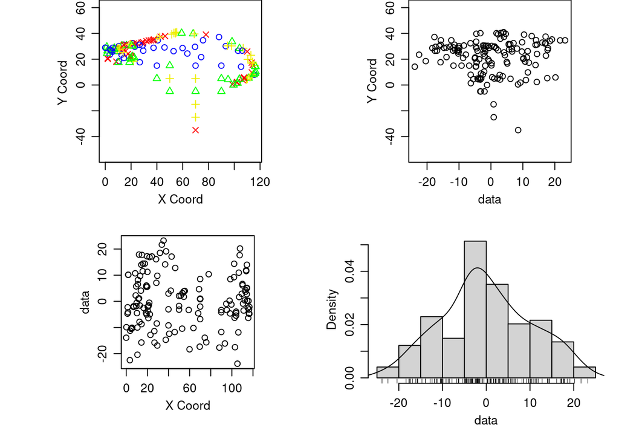

```r
angle <- 0 # No rotation in this case, only "squishing".
ratio <- 2
elevs2.ani <- cbind(coords.aniso(geoelevs2$coords, c(angle,ratio),reverse = FALSE),geoelevs2$data)
geoelevs2.ani <- as.geodata(elevs2.ani)
plot(geoelevs2.ani)
```

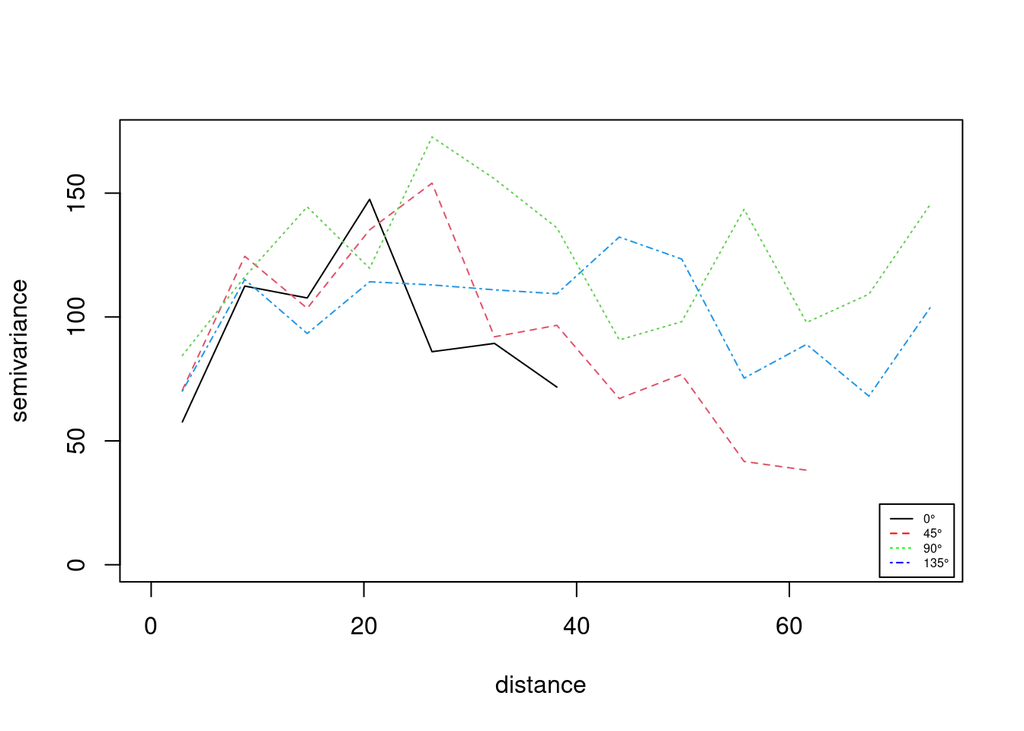

```r
par(mfrow=c(1,1))
variod.ani <- variog4(geoelevs2.ani, max.dist=maxdist/2, pairs.min=30,estimator.type = "modulus");
plot(variod.ani,lyt=2,legend=FALSE,main="Anisotropy angle=0,ratio=2")
legend(x="bottomright", inset=0.01, lty=c(1,2,3,4), col=c("black", "red", "green","blue"),
       legend=c("0\u00B0", "45\u00B0", "90\u00B0","135\u00B0"), cex=0.5)
```

Making the same plots as earlier, to see if the process looks more isotropic.

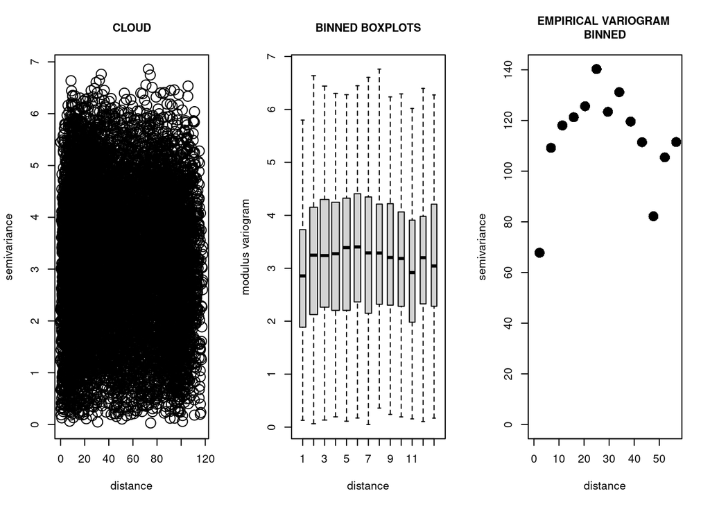

```r
maxdist2 <- max(dist(cbind(elevs2.ani[,1],elevs2.ani[,2]))) # Practical rules: lags only up to half of maxdist. That is why this is saved here.
cloud2 <- variog(geoelevs2.ani, option = "cloud", estimator.type = "modulus")
bp2 <- variog(geoelevs2.ani, option = "bin", bin.cloud = T,
             pairs.min=30, max.dist=maxdist2/2,
             estimator.type = "modulus") # Not sure about all these arguments.
bin2 <- variog(geoelevs2.ani, option = "bin", pairs.min=30, max.dist=maxdist2/2,
              estimator.type = "modulus")
# Also: pairs.min = 30 since the sample variogram should only be considered for lags that have more than 30 pairs.

par(mfrow=c(1,3))
plot(cloud2,main="CLOUD", cex.main=1, cex.lab=1, cex=2)
plot(bp2, bin.cloud=T, cex.lab=1)
title(main = "BINNED BOXPLOTS", cex.main=1)
plot(bin2, main="EMPIRICAL VARIOGRAM \nBINNED",cex.main=1, cex.lab=1, cex=2, pch=16)
```

Below we compare the sample variograms before and after the transformation.

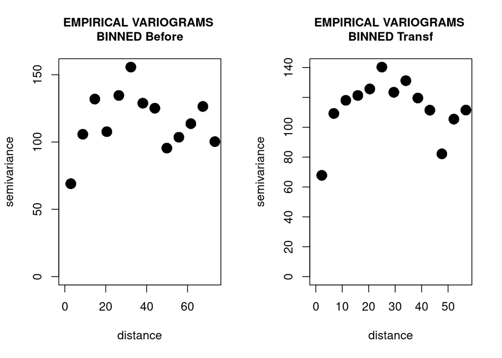

```r
par(mfrow=c(1,2))
plot(bin, main="EMPIRICAL VARIOGRAMS \nBINNED Before",cex.main=1, cex.lab=1, cex=2, pch=16)
plot(bin2, main="EMPIRICAL VARIOGRAMS \nBINNED Transf",cex.main=1, cex.lab=1, cex=2, pch=16)
```

It looks like the sills are different.